# PSY 5939: Longitudinal Data Analysis

# 1 Introduction to longitudinal data

# 1.1 Longitudinal data

# 1.1.1 What is longitudinal data?

Longitudinal data is

- *repeated* observations
- of *multiple units*
- of the *same variable*
- from the *same unit or participant*
- over *time*

# 1.1.2 What **isn’t** longitudinal data?

Prospective data

- Variable A at time 1 predicts variable B at time 2
- Not measuring the same variable repeatedly

Repeated surveys over time of different people

- e.g., political polls that ask a different group each time
- Not measuring the same unit on each occasion

Time series

- 1 unit measured over time
- Not measuring multiple units

# 1.1.3 Advantages of longitudinal data

We can answer research questions about **change over time**

- Change over time, such as development or aging over time
- Is change **homogeneous** across all individuals?
- **Predictors of change** at the group or individual level
- **Change as a predictor** of other outcomes

We can also use longitudinal data to clarify time sequencing to strengthen *causal inference*

# 1.1.4 Challenges of longitudinal data

Collecting, maintaining, and analyzing longitudinal data has particular challenges

- Requires at least 2, preferably 3 or more waves of data
- Outcome of interest may change over time
- Need a sensible metric for time that is measured
- Data management and subject tracking
- Missing data and attrition are more common than in cross-sectional data

# 1.2 Approaches

# 1.2.1 Statistical models of change

There are *many* types of statistical analyses for longitudinal data

Vary in terms of how they assess change:

- Individual versus group
- Difference versus trajectory
- Discrete versus continuous change
- Software used

This course will cover a variety of methods that are **commonly used in psychology** and other social and behavioral sciences

# 1.2.2 What we will cover

- Regression-based methods for 2 waves of data
  - Differences, controlling for baseline (ANCOVA), partial change
- Mixed (or multilevel or hierarchical linear or random effects) models
  - Focus on individual change and variability
- Latent growth models
  - Focus on individual change and variability
- Statistical mediation
  - How a causal process unfolds over time

# 1.2.3 What we won’t cover

- Repeated-measures ANOVA
  - Limited utility. Assumptions typically violated
- Auto-regressive and cross-lag models
  - Often interpreted incorrectly. Better alternatives
- Survival analysis
  - Not commonly used in psychology
- Time series analysis
  - We will focus on models for multiple units

# 1.3 Measurement

# 1.3.1 Measurement issues for longitudinal data

Newsom, Jones, and Hofer, 2012, Chapter 4

> The study of change rests on the assumption that observed differences in measurements over time reflect **true change in the construct** being measured.

Why are you seeing change over time?

- Is the construct actually changing?
- Is how you’re measuring the construct changing?
  - In other words, is it changing in a meaningful way?

# 1.3.2 Measurement issues: Reliability change

- Reliability of the construct may change over time
  - Become more or less reliable over time
- May distort results significantly
  - How much depends on method
- Also, reliability of change itself

# 1.3.3 Measurement issues: Construct change

- Many constructs, by their nature, change over time
  - e.g., smoking as a measure of deviant behavior (10 vs 20)
- Change over time may be masked by change in the construct
- Construct may be stable but measure may change

# 1.3.4 Measurement issues: Measuring time

How we measure **time** is absolutely key

- **Actual time** between observations versus **waves**
- Time measurement **varies** across individuals
- **When** we measure impacts whether we can detect change

# 1.4 Data issues

# 1.4.1 Dataset issues for longitudinal data

There are two ways that your data may be organized

- Person-level structure
  - also called multivariate or wide
  - Typical for cross-sectional data
- Person-period structure
  - also called univariate, tall, or stacked
  - Typical for longitudinal data

# 1.4.2 Person-level (wide)

- Rows for participants (1 row per **person**)
- Columns for variables
- Different timepoints are different variables / columns
- Typical structure for cross-sectional data
- Preferred structure for latent growth models in Mplus

# 1.4.3 Wide data

| ID | extern1 | extern2 | extern3 | extern4 | extern5 |
| --- | --- | --- | --- | --- | --- |
| 1 | 4 | 3 | 4 | 4 | 5 |
| 2 | 3 | 5 | 4 | 4 | 3 |
| 3 | 2 | 3 | 3 | 5 | 3 |
| 4 | 4 | 5 | 3 | 5 | 3 |
| 5 | 5 | 3 | 4 | 4 | 3 |

# 1.4.4 Person-period (tall or stacked)

- Multiple rows per participant
- 1 row per participant, **per timepoint**
- Preferred format for most programs for mixed models
- Also easier to include time-varying variables

# 1.4.5 Tall data

| ID | time | extern |
| --- | --- | --- |
| 1 | 1 | 4 |
| 1 | 2 | 3 |
| 1 | 3 | 4 |
| 1 | 4 | 4 |
| 1 | 5 | 5 |
| 2 | 1 | 3 |
| 2 | 2 | 5 |
| 2 | 3 | 4 |
| 2 | 4 | 4 |
| 2 | 5 | 3 |
| 3 | 1 | 2 |
| 3 | 2 | 3 |
| 3 | 3 | 3 |
| 3 | 4 | 5 |
| 3 | 5 | 3 |
| 4 | 1 | 4 |
| 4 | 2 | 5 |
| 4 | 3 | 3 |
| 4 | 4 | 5 |
| 4 | 5 | 3 |
| 5 | 1 | 5 |
| 5 | 2 | 3 |
| 5 | 3 | 4 |
| 5 | 4 | 4 |
| 5 | 5 | 3 |

# 1.5 Missing data

# 1.5.1 Missing data in longitudinal studies

“Missingness” refers to whether someone has a value on a particular variable or not

- Missing values on *items* or entire *scales*

Longitudinal studies have an additional issue of **attrition**

- Participants are involved in some waves but then drop out
- These participants may or may not return for later waves

# 1.5.2 Oversimplified review of missing data mechanisms

Imagine that you have 2 variables: X and Y  
Y has some missing values

**MCAR**: Missingness on Y is unrelated to values of X and unrelated to the (missing) values of Y itself

**MAR**: Missingness on Y is unrelated the (missing) values of Y, but it is related to values of X

**MNAR**: Missingness on Y is related to the (missing) values of Y

See Baraldi & Enders (2010), Enders (2010) for more information

- Or take Tim Hayes’ Missing Data course

# 2 Regression review

# 2.1 Terminology

# 2.1.1 Terminology for regression

**Dependent variable**, also called

- Y
- criterion
- outcome
- response variable
- regressand
- explained variable
- effect

# 2.1.2 Terminology for regression

**Independent variable**, also called

- X
- predictor
- explanatory variable
- regressor
- manipulated variable
- cause

# 2.2 General linear model

# 2.2.1 General linear model

General method to predict a continuous outcome

Continuous and/or categorical predictors and regression weights

ANOVA and linear regression are examples of GLM

# 2.2.2 General linear model

$Y_i = b_0 + b_1X_1 + b_2X_2 + ... + b_pX_p + e_i$

or

$\hat{Y}_i = b_0 + b_1X_1 + b_2X_2 + ... + b_pX_p$

- $Y_i$ is the **observed** outcome for individual $i$
- $\hat{Y}_i$ is the **predicted** outcome for individual $i$
- The $X$s are the predictor variables
- The $b$s are the regression coefficients or weights
- $e_i$ is the error or residual term for individual $i$

# 2.3 Assumptions

# 2.3.1 Assumptions 1

Linear regression and ANOVA models are estimated using ordinary least squares (OLS) estimation

In order for OLS estimates of regression coefficients to be the **best linear unbiased estimates (BLUE)** of the population regression coefficients, we make three assumptions about the residuals ($e_i$):

1. Average or expected value of the residuals is 0
2. Variance of the residuals is constant across values of the predictor and greater than 0
3. **Errors for individual observations are uncorrelated**

# 2.3.2 Assumptions 2

We make a 4th assumption to allow for statistical inference (i.e., significance tests)

4. Errors have a (conditionally) normal distribution

This 4th assumption means that we can replace assumption 3 with the stronger assumption that individual errors are **independent** (not just uncorrelated)

# 2.3.3 Independence of observations

One observation’s values do not depend on another observations values

Independence is a stronger assumption than uncorrelated

- Independence **implies** NO correlation
- No correlation **does not imply** independence

Non-independence occurs because of clustering of observations in groups (e.g., families, classrooms) or **repeated observations on the same person over time**

# 2.4 Interpreting effects

# 2.4.1 Interpreting linear regression effects

$\hat{Y}_i = b_0 + b_1X_1 + b_2X_2 + ... + b_pX_p$

The effect of each predictor is a *partial* effect

- **Controlling for** or **holding constant** the effects of all other predictors

Linear, additive effects

- For a 1 unit increase in $X_1$, there is a $b_1$ unit increase in the predicted outcome (**holding all other predictors constant**)

# 2.4.2 Linear effect

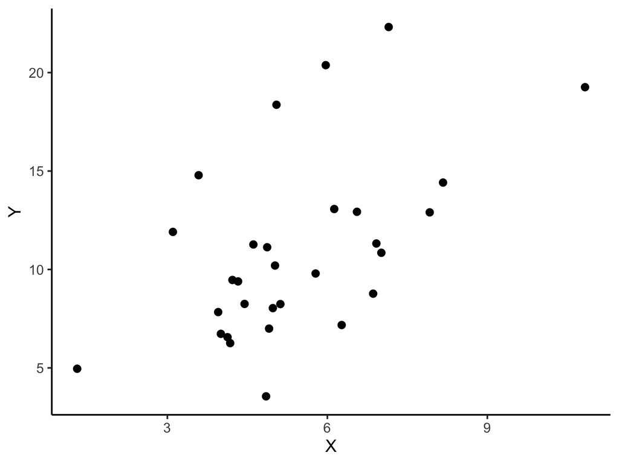

# 2.4.3 Linear effect

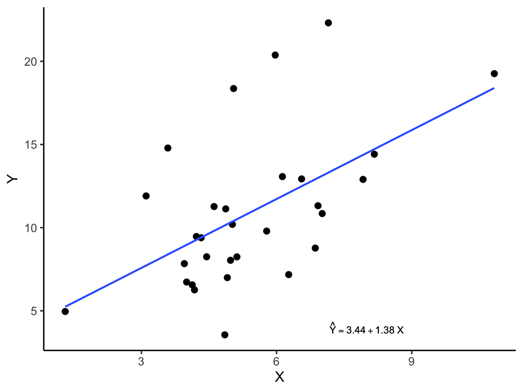

# 2.5 Interactions

# 2.5.1 Interaction effects in linear regression

$\hat{Y}_i = b_0 + b_1X + b_2Z + b_3XZ$

**Interaction** or **moderation** is included as a product term

The effect of $X$ on $Y$ depends on the level of $Z$

- Equivalently, the effect of $Z$ on $Y$ depends on the level of $X$

# 2.5.2 Plot of Y versus X (colored by Z)

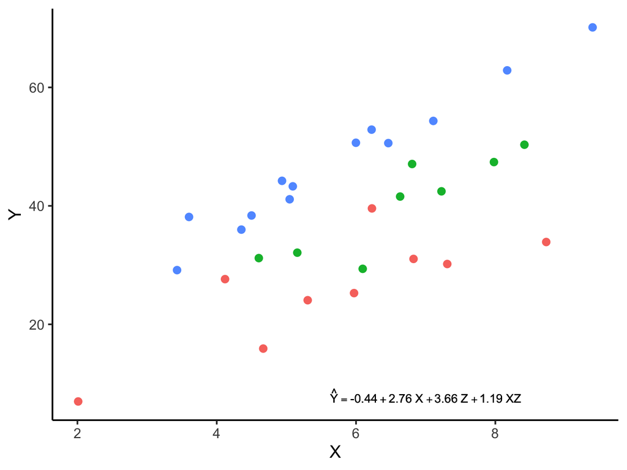

# 2.5.3 With simple slopes at the levels of Z

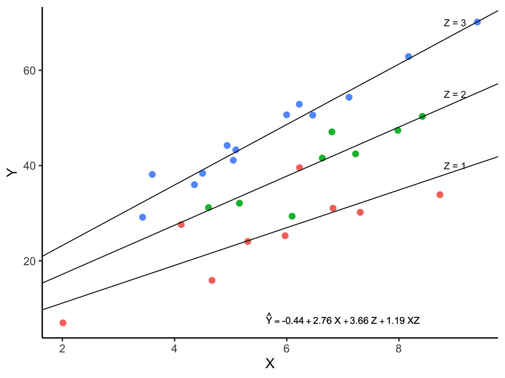

# 2.5.4 Interpretation

$\hat{Y}_i =$ -0.44 $+$ 2.76$X +$ 3.66$Z +$ 1.19$XZ$

- -0.44 ($b_0$) is the expected value of Y **when both $X$ and $Z$ equal 0**
- 2.76 ($b_1$) is the effect of X on Y (slope) **when $Z$ = 0**
- 3.66 ($b_2$) is the effect of Z on Y (slope) **when $X$ = 0**

But both $X$ = 0 and $Z$ = 0 are outside of the range of data points

- $X$ and $Z$ effects are not meaningful
- We can **center** predictors to make interpretation more meaningful
- We often use the mean of the predictor, but can use other values

# 2.5.5 Centering at the mean

We often center at the *mean* of the variable (but not always!)

The mean for $X$ is 6.6  
Center X by subtracting the mean from each observation

| X | minus | Xmean | equals | Xcent |
| --- | --- | --- | --- | --- |
| 3 | – | 6.6 | = | -3.6 |
| 4 | – | 6.6 | = | -2.6 |
| 10 | – | 6.6 | = | 3.4 |
| 10 | – | 6.6 | = | 3.4 |
| 6 | – | 6.6 | = | -0.6 |

The mean of X is 6.6  
The mean of Xcent is 0 (actual calc to 2 decimal places)

# 2.5.6 Centered interaction

$\hat{Y}_i = b_0 + b_1Xcent + b_2Zcent + b_3XcentZcent$

- Use the new centered predictors, $Xcent$ and $Zcent$
- Note: The interaction term uses the **product** of the centered terms

# 2.5.7 Plot of Y versus Xcent (colored by Zcent)

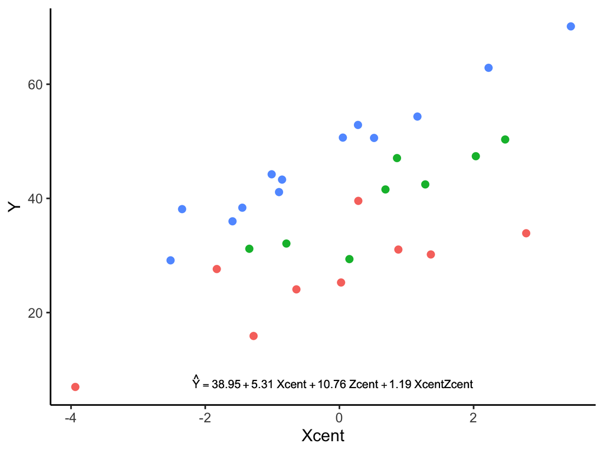

# 2.5.8 With simple slopes at the levels of Zcent

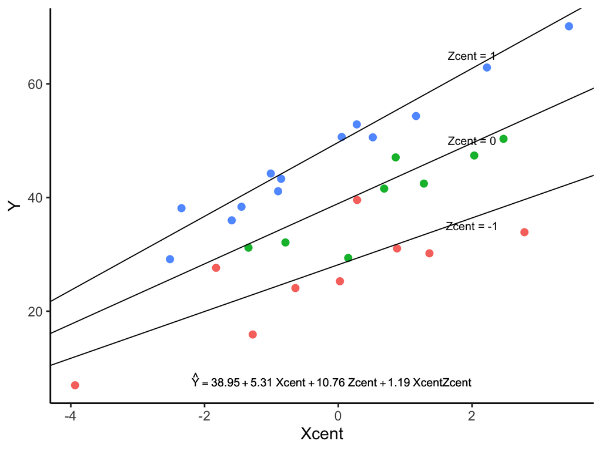

# 2.5.9 Centered interpretation

$\hat{Y}_i =$ 38.95 $+$ 5.31$Xcent +$ 10.76$Zcent +$ 1.19$XcentZcent$

- 38.95 ($b_0$) is the expected value of $Y$ **when both $Xcent$ and $Zcent$ equal 0**
  - Expected value of $Y$ **for the middle $Z$ group, at the mean of $X$**
- 5.31 ($b_1$) is the effect of $Xcent$ on $Y$ (slope) **when $Zcent$ = 0**
  - Expected increase in $Y$ for a 1 unit increase in $Xcent$ **for the middle $Z$ group**
- 10.76 ($b_2$) is the effect of $Zcent$ on $Y$ (slope) **when $Xcent$ = 0**
  - Expected increase in $Y$ for a 1 unit increase in $Zcent$ **at the mean of $X$**

# 2.5.10 Why do we center?

To aid interpretation in any model with an *interaction* or an *intercept*

**Centering** will be especially important:

- Centering in mixed models to get accurate estimates
- Centering in growth models to get interpretable intercepts
  - Does it make sense to talk about effects at age = 0?

For more information on **centering**, see Aiken and West (1991) and Jaccard, Wan, and Turrisi (1990)

# 3 SEM review / crashcourse

# 3.1 SEM overview

# 3.1.1 For this course

I do NOT expect you to know structural equation modeling

- If you do: awesome!
  - Here is a refresher on some SEM topics relevant to this course
- If you don’t: no problem!
  - I will cover the basics of SEM and some terminology I’ll use in the next 20 minutes or so

# 3.1.2 Structural equation modeling

Structural equation modeling (SEM) is a general method of statistical data analysis that allows:

- Complex modeling
- Multiple outcome variables
- Unobserved (latent) variables
- and more

ANOVA, linear regression, path analysis, and factor analysis are all special cases of SEM

# 3.1.3 What is SEM?

Basically

- SEM lets you simultaneously solve several regression equations
- SEM also allows you to model measurement error

It is also really easy to represent SEMs using a graphical format (i.e., path models), rather than equations

- Matrices and equations underlie SEM, but the graphical format is a lot easier to start with

# 3.2 SEM graphical notation

# 3.2.1 Observed variables

Observed or manifest variables are actually measured

Observed variables are represented by **squares**

- In a study, we ask people how old they are (in years)
- “Age” is an observed variable; in a model, it would look like:

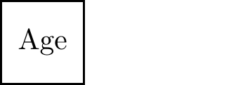

# 3.2.2 Latent variables

Latent or unobserved variables are not actually measured

Latent variables are represented by **circles**

- In a study, we are interested in intelligence, but we don’t actually measure intelligence directly
- “Intelligence” is a latent variable; in a model, it would look like:

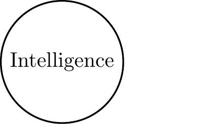

# 3.2.3 Means / intercepts

Means and intercepts are represented as a triangle with the number 1 in it

They are often omitted in figures unless they are specifically relevant to the model

They are important in certain models, so keep them in mind

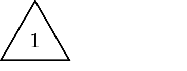

# 3.2.4 Prediction

Prediction is represented by an **arrow** from the predictor variable to the outcome variable

X predicts Y looks like:

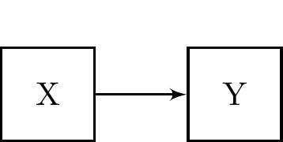

# 3.2.5 Correlation

Correlation is represented by a **double-headed arrow** between the correlated variables

These arrows are often *curved* but they don’t have to be

X is correlated with Y looks like:

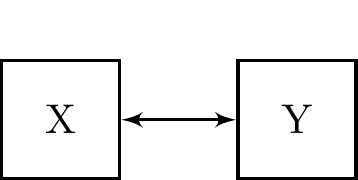

# 3.2.6 Y predicted by X1 and X2

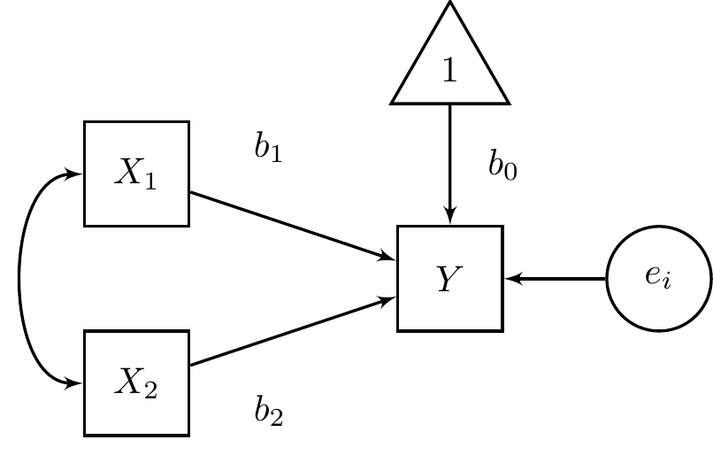

# 3.3 Applications

# 3.3.1 Measurement error

Measurement error reflects the discrepency between a measured score and unobserved “true score”

We don’t directly measure intelligence, but we can try to measure it indirectly, with an IQ test

But there will be some **error** in our measurement and we can include that error in the model

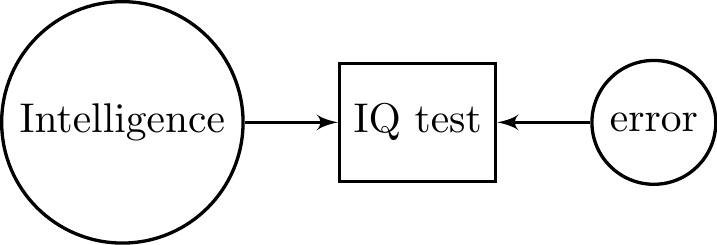

# 3.3.2 Factor analysis

Discover a single underlying (latent) factor that explains the variance in a set of observed variables

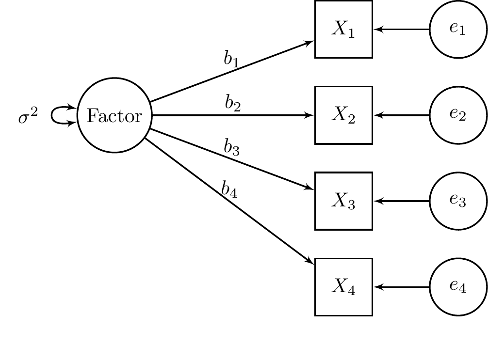

# 3.3.3 Mediation

Statistical mediation occurs when three variables occur in a causal chain, such that X causes M, which then causes Y

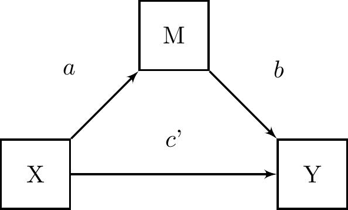

# 3.3.4 Regression with latent variables

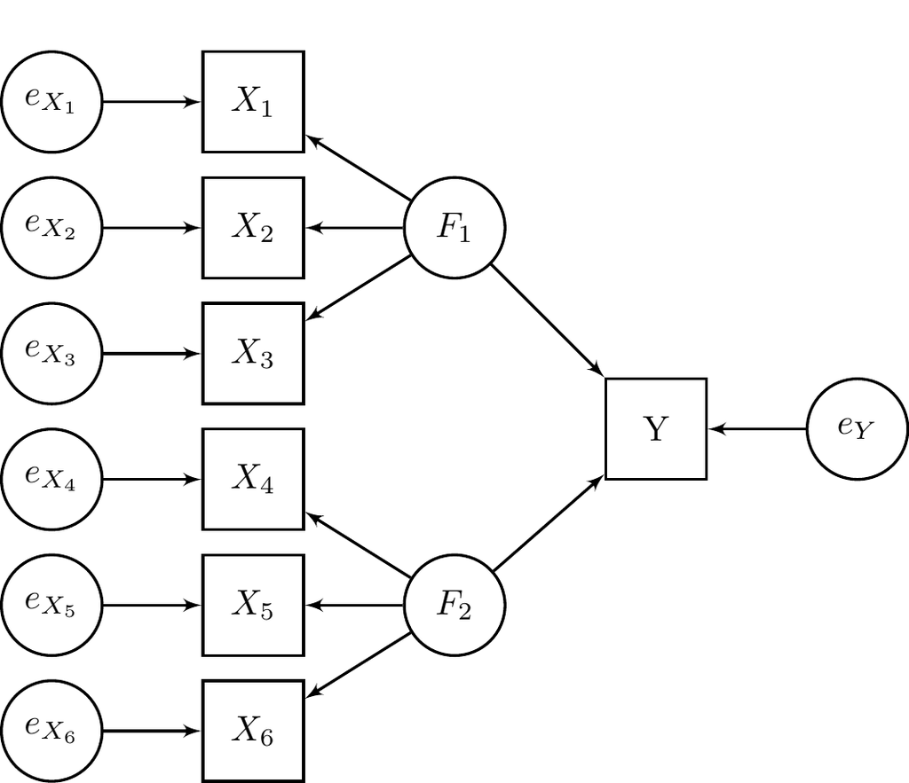